# Laporan 2 - Twit tentang Teluk Benua

Ujang fahmi

4/30/2018

# 1 Pendahuluan

```r
# Runing RJava
if (Sys.info()['sysname'] == 'Darwin') {
  libjvm <- paste0(system2('/usr/libexec/java_home',stdout = TRUE)[1],'/jre/lib/server/libjvm.dylib')
  message (paste0('Load libjvm.dylib from: ',libjvm))
  dyn.load(libjvm)
}
library(tidyverse)
library(tidytext)
library(ggplot2)
library(stringr)
library(lubridate)
library(topicmodels)
library(tm)
library(RWeka)
library(reshape2)
library(wordcloud)
library(igraph)
library(ggraph)
library(quanteda)
library(googledrive)
library(textclean)
library(knitr)
```

# 2 Data

```r
id0 <- "1RAalTLYhpprDCpE_wos48ymufN8mjMG_" # twit-mention-change.csv
id1 <- "11WTedaaE79EtT4vOGNU2vfG7xgcLtJcE" # twit-tagar-balitolakreklamasi.csv
id2 <- "1984jmFur63PmYvoC8Ab6P2iwfUQYVp71" # twit-tagar-balinotforsale.csv
id3 <- "1Pw0WZIuou9bw7nog1xCJqOVZDR-TCk88" # cleaned username_all
twit_to_change <- read_csv(sprintf("https://docs.google.com/uc?id=%s&export=download", id0))
btr_raw <- read_csv(sprintf("https://docs.google.com/uc?id=%s&export=download", id1))
bns_raw <- read_csv(sprintf("https://docs.google.com/uc?id=%s&export=download", id2))
net_telukBenua <- read_csv(sprintf("https://docs.google.com/uc?id=%s&export=download", id3))
```

```r
tb_raw <- bind_rows(btr_raw, bns_raw)
tb_raw$tweets <- replace_white(tb_raw$tweets) # replacing white space
tb_raw$tweets <- replace_non_ascii(tb_raw$tweets, remove.nonconverted = TRUE)
# print is duplicate
tb_raw %>%
  group_by(is_duplicate) %>%
  count(is_duplicate) %>%
  summarise(jumlah = n) %>%
  kable()
```

| is_duplicate | jumlah |
| --- | --- |
| FALSE | 119438 |
| TRUE | 25844 |

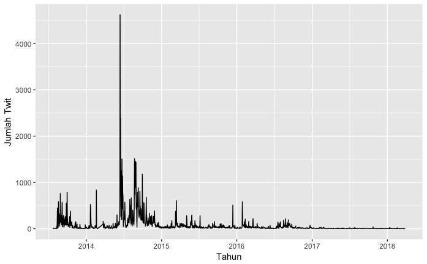

```r
tb_raw <- tb_raw %>%
  filter(is_duplicate == FALSE)
tb_raw %>%
  group_by(date) %>% count(date) %>% arrange(date) %>%
  ggplot(aes(x = date, y = n)) + geom_line(show.legend = FALSE) +
  labs(x = "Tahun", y = "Jumlah Twit")
```

# 3 Analisis Aktor

Aktor dalam twit merupakan username atau nama akun yang terdapat dalam twitter. Aktor dibedakan menjadi, yaitu aktor sebagai pengirim twit yang selanjutnya disebut pengirim dan aktor yang terlibat. Aktor yang terlibat juga dapat menjadi aktor pengirim twit, namun di sini aktor terlbat didapat dari body twit yang posisinya berada setelah akun pertama yang dianggap sebagai pengirim.

## 3.1 Akun pengirim

```r
tb_raw %>%
  filter(is_duplicate == FALSE) %>%
  count(user, sort = TRUE) %>%
  filter(!str_detect(user, 'ChangeOrg_ID')) %>%
  head(n = 20) %>%
  ggplot(aes(x = reorder(user, n), y = n)) + coord_flip() +
  geom_col(show.legend = FALSE) +
  labs(x = "Username Twitter", y = "Jumlah Twit yang dikirim")
```

[output not shown]

Selain akun `ForBALI13` juga terdapat beberapa akun lain yang cukup banyak mengirimkan twit tentang tolak reklamasi teluk benoa. Akun-akun tersebut juga rata-rata memiliki follower cukup banyak. Hal ini membuat twit tentang tolak reklamasi menyebar cukup cepat. Hal ini juga menjadi salah satu strategi gerakan dengan melibatkan “artis” atau aktor yang telah lebih dulu populer. Sebagai contoh, JRX_SID yang juga merupakan anggota band SID memiliki 364 ribu lebih follower Twitter.

## 3.2 Akun terlibat

```r
net_telukBenua %>%
  unnest_tokens(user, Data, to_lower = FALSE) %>%
  count(user, sort = TRUE) %>%
  filter(!str_detect(user, 'ChangeOrg_ID')) %>%
  head(n = 20) %>%
  ggplot(aes(x = reorder(user, n), y = n)) + coord_flip() +
  geom_col(show.legend = FALSE) +
  labs(x = "Username Twitter", y = "Jumlah Keberadaan Username dalam Twit")
```

[output not shown]

## 3.3 Social network analysis

Network analysis dilakukan melalui perangkat lunak gephi, termasuk perhitungan komponen dari network seperti modularity, dan centrality. Di mana `nodes` merupakan username Twitte dan `edges` merupakan keberadaan dalam twit yang sama atau `cooccurrance.`

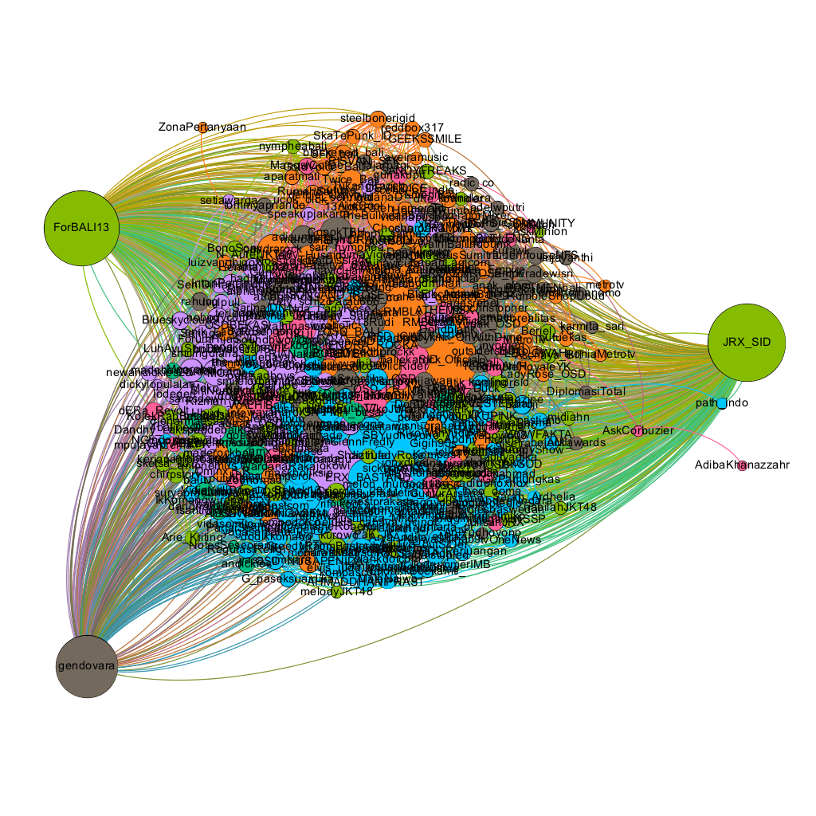

**Keterangan:** Warna dalam gambar dibuat berdasarkan *modularity class* dan besar nodes dibuat berdasarkan *eigenvector centrality*. Gambar hanya menampilkan nodes dengan minimum degree 20.

Gambar di bawah ini menunjukkan bahwa pengguna twitter tidak memiliki perbedaan yang cukup mencolok karena masing-masing akun berada cukup berdekatan satu sama lain. Di satu sisi hal tersebut dapat menjadi indikator positif yang menunjukkan adanya kesamaan pandangan tentang reklamasi. Di sisi lain, keberadaannya yang cukup berdekatan tersebut juga menjadi salah satu indikator adanya satu aktor kunci yang cukup dominan. Hal tersebut bukan hal yang buruk, namun ketika terjadi akun tersebut berhenti dapat memengaruhi gerakan secara keseluruhan. Gambar berikut menunjukkan posisi 10 akun dengan `eigencentrality` tertinggi.

```r
id4 <- "1WImYxfSR8Nzutfv8ZV74Xa_O2GTZ2zye" # network analysis
net_analysis <- read_csv(sprintf("https://docs.google.com/uc?id=%s&export=download", id4))

net_analysis %>%
  select(Label, eigencentrality) %>%
  arrange(desc(eigencentrality)) %>%
  head(n = 10) %>%
  ggplot(aes(reorder(Label, eigencentrality), eigencentrality)) +
  coord_flip() + geom_col() +
  labs(x = "Nama Akun", y = "eigencentrality")
```

[output not shown]

Kenapa media sosia? dapat dijawab dengan data dari media serta hasil wawancara dengan **gendovara**.

# 4 Analisis Konten

## 4.1 Tagar

Tagar merupakan salah satu indikator utama yang dapat digunakan untuk melihat sebuah konten media sosial. Dalam hal ini, tagar sering digunakan oleh pengguna media sosial sebagai penanda sebuah pembahasan, termasuk dalam Twitter.

```r
tagar_periode1 <- tb_raw %>%
  filter(periode == "periode_1") %>%
  select(hashtag, tag_count) %>%
  filter(tag_count >= 1) %>%
  unnest_tokens(tagar, hashtag) %>%
  count(tagar, sort = TRUE)

tagar_periode2 <- tb_raw %>%
  filter(periode == "periode_2") %>%
  select(hashtag, tag_count) %>%
  filter(tag_count >= 1) %>%
  unnest_tokens(tagar, hashtag) %>%
  count(tagar, sort = TRUE)

tagar_periode3 <- tb_raw %>%
  filter(periode == "periode_3") %>%
  select(hashtag, tag_count) %>%
  filter(tag_count >= 1) %>%
  unnest_tokens(tagar, hashtag) %>%
  count(tagar, sort = TRUE)

tagar_periode <- bind_rows(tagar_periode1 %>%
                             mutate(periode = "periode_1"),
                           tagar_periode2 %>%
                             mutate(periode = "periode_2"),
                           tagar_periode3 %>%
                             mutate(periode = "periode_3"))

tagar_periode %>%
  #filter(!str_detect(tagar, 'balitolakreklamasi')) %>%
  #filter(!str_detect(tagar, 'balinotforsale')) %>%
  filter(!str_detect(tagar, 'tolakreklamasi')) %>%
  filter(!str_detect(tagar, 'nw')) %>%
  filter(!str_detect(tagar, 'np')) %>%
  filter(!str_detect(tagar, 'ff')) %>%
  filter(!str_detect(tagar, 'indonesia')) %>%
  filter(!str_detect(tagar, 'repost')) %>%
  filter(!str_detect(tagar, 'share')) %>%
  filter(!str_detect(tagar, 'bali')) %>%
  filter(!str_detect(tagar, '2')) %>%
  filter(!str_detect(tagar, '1')) %>%
  filter(!str_detect(tagar, '4')) %>%
  filter(!str_detect(tagar, '5')) %>%
  filter(!str_detect(tagar, '3')) %>%
  group_by(periode) %>%
  top_n(15, n) %>%
  ggplot(aes(reorder(tagar, n), n, fill = periode)) +
  geom_col(show.legend = FALSE) +
  facet_wrap(~ periode, scales = "free", ncol = 3) +
  coord_flip() +
  labs(x = "Tagar",
       y = "Jumlah twit yang diunggah")
```

[output not shown]

Secara umum tagar-tagar yang digunakan oleh pengguna Twitter mengalami perkembangan dari waktu ke waktu. Hal ini sejalan dengan salah satu pernyataan dari nara sumber yang mengatakan bahwa tagar yang digunakan dipilih dan disesuaikan dengan momen yang berkembang saat itu. Bali not for sale sendiri telah lebih dulu digunakan dibanding tagar balitolakreklamasi, dan setelahnya tagar terus berkembang hingga pada akhir periode ada juga tagar **#kecewaamasusi**. Tagar kecewaamasusi diantaranya dapat dilihat pada twit-twit berikut ini.

```r
tb_raw %>%
  filter(is_duplicate == FALSE) %>%
  filter(str_detect(tweets, "#KecewaAmaSusi")) %>%
  arrange(desc(ret_count)) %>%
  select(user, date, tweets) %>%
  head(n = 5) %>%
  kable() %>%
  kable_styling()
```

[output not shown]

Kasus ini sendiri muncul karena pada waktu itu, ijin reklamasi akan segara habis dan harus mendapat perpanjangan ijin. Pemeberian ijin menjadi salah satu kewenangan yang dapat diberikan oleh menteri kelautan, yaitu Susi. Namun, menurut penuturan salah seorang partisipan menteri tersebut memilih untuk diam, sehingga secara otomatis ijin pun berlanjut. Karena hal tersebutlah kemudian mereka membuat tagar **#KecewaAmaSusi**.

## 4.2 Term

Term atau kata diambil dari isi twit selain usernme dan tagar. Gambar di bawah ini menunjukkan term dalam bentuk bigram. Di mana bigram dibuat berdasarkan keberadaan term dalam twit yang sama. Misalnya, sebuah twit berisi kalimat **“aku suka makan nasi”** maka bigram yang dapat dibuat dari kalimat tersebut adalah **“aku suka”**, **“suka makan”**, dan **“makan nasi.”**

```r
tb_raw %>%
  filter(is_duplicate == FALSE) %>%
  filter(word_count >= 2) %>%
  select(date, clean_text, word_count, periode) %>%
  unnest_tokens(kata, clean_text, token = "ngrams", n = 2) %>%
  count(kata, sort = TRUE) %>%
  head(n = 20) %>%
  ggplot(aes(reorder(kata, n), n)) + geom_col() + coord_flip() +
  labs(x = "bigram", y = "jumlah bigram")
```

[output not shown]

Kata atau pasangan kata berikutnya juga dapat dinterpretasikan dengan pola yang sama, yaitu dengan merujuk pada cerita baik yang didapat dari data darat. Interpretasi juga dapat dilakukan dengan merujuk pada hasil `close reading` twit aktor utama.

## 4.3 Semantic network

Selain dengan bigram di atas, hubungan antar kata dari sebuah korpus juga dapat dilihat melalui semantic network. Di mana satu term memiliki hubungan dengan term lain berdasarkan keberadaannya. Gambar di bawah ini menunjukkan hubungan antar term yang terjadi minimal 100 kali.

```r
bigram_counts <- tb_raw %>%
  filter(is_duplicate == FALSE) %>%
  filter(word_count >= 2) %>%
  select(clean_text) %>%
  unnest_tokens(bigram, clean_text, token = "ngrams", n = 2) %>%
  count(bigram, sort = TRUE) %>%
  separate(bigram, into = c("word1", "word2"))

library(widyr)

bigram_counts %>%
  filter(n >= 100) %>%
  graph_from_data_frame() %>%
  ggraph(layout = "fr") +
  geom_edge_link(aes(edge_alpha = n, edge_width = n), edge_colour = "cyan4") +
  geom_node_point(size = 5) +
  geom_node_text(aes(label = name), repel = TRUE,
                 point.padding = unit(0.2, "lines")) +
  theme_void()
```

[output not shown]

**Twit dengan kata kunci tv**

```r
tb_raw %>%
  filter(is_duplicate == FALSE) %>%
  filter(str_detect(tweets, "Tv")) %>%
  arrange(desc(ret_count)) %>%
  select(user, date, tweets) %>%
  head(n = 5) %>%
  kable() %>%
  kable_styling()
```

[output not shown]

**Twit dengan kata kunci kompas tv**

```r
tb_raw %>%
  filter(is_duplicate == FALSE) %>%
  filter(str_detect(tweets, "Kompas TV")) %>%
  arrange(desc(ret_count)) %>%
  select(user, date, tweets) %>%
  head(n = 5) %>%
  kable() %>%
  kable_styling()
```

[output not shown]

## 4.4 Tf-idf

Penjelasan tentang TF-IDF secara umum dapat ditemukan di sini. Secara umum TF-IDF merupakan sebuah upaya untuk menemukan term yang penting dalam sebuah dokumen dengan membandingkan frekuensi dalam dokumen yang spesifik dengan frekuensi dalam dokumen secara umum. Sebagai ilustrasi, kita dapat menemukan term yang hampir pasti memiliki frekuensi yang tinggi dalam setiap dokumen, misalnya kata di, dan dan dalam. Kata-kata tersebut sering disebut *stopwords*. Namun karena kata tersebut tidak bersifat unik, dan juga ada dalam dokumen yang lain, maka nilai tf-idfnya akan turun. Sebaliknya, jika sebuah term memiliki frekuensi tinggi dalam sebuah dokumen dan tidak dalam dokumen yang lain, kata atau term tersebut akan memiliki nilai yang tinggi. Gambar di bawah ini, menunjukkan kata-kata dengan tf-idf tertinggi dalam setiap periode.

```r
twit_words <- tb_raw %>%
  filter(is_duplicate == FALSE) %>%
  filter(word_count >= 2) %>%
  select(clean_text, periode) %>%
  group_by(periode) %>%
  unnest_tokens(kata, clean_text, token = "ngrams", n = 2) %>%
  count(kata, sort = TRUE)

total_words <- twit_words %>%
  group_by(periode) %>%
  summarise(total = sum(n))

twit_words <- left_join(twit_words, total_words)

twit_words <- twit_words %>%
  bind_tf_idf(kata, periode, n) %>%
  arrange(desc(tf_idf))

# Visualisasi tf-idf
twit_words %>%
  arrange(desc(tf_idf)) %>%
  mutate(kata = factor(kata, levels = rev(unique(kata)))) %>%
  group_by(periode) %>%
  top_n(10) %>%
  ungroup %>%
  ggplot(aes(reorder(kata,tf_idf), tf_idf, fill = periode)) +
  geom_col(show.legend = FALSE) +
  facet_wrap(~periode, ncol = 2, scales = "free") +
  labs(x = "Bigram", y = "Value") +
  coord_flip()
```

[output not shown]

```r
tb_raw %>%
  filter(is_duplicate == FALSE) %>%
  filter(periode == "periode_1") %>%
  filter(!str_detect(tweets, "RT")) %>%
  filter(str_detect(clean_text, "dprd berperang")) %>%
  select(user, date, tweets) %>%
  head(n = 5) %>%
  kable() %>%
  kable_styling()
```

[output not shown]

Sementara dalam periode dua, kita menemukan term yang cukup unik yaity **ve fooled**. Tanpa membaca lebih jauh term tersebut susah untuk diinterpretasikan. Untuk itu, beberapa twit di bawah ini mungkin dapat memberikan gambaran tentang isi twit dengan kata tersebut.

```r
tb_raw %>%
  filter(is_duplicate == FALSE) %>%
  filter(periode == "periode_2") %>%
  filter(!str_detect(tweets, "RT")) %>%
  arrange(desc(ret_count)) %>%
  filter(str_detect(clean_text, "ve fooled")) %>%
  select(user, date, tweets) %>%
  head(n = 5) %>%
  kable() %>%
  kable_styling()
```

[output not shown]

Dari twit di atas, ternyata term **ve fooled** berkaitan dengan keberadaan Cristiano Ronaldo ke Bali. Term ve sendiri ternyata berasal dari ’ve fooled atau u’ve been fooled. Dengan kata lain, melalui term tersebut kita dapat mengetahui bahwa warga net menganggap Cristiano telah dibohongi oleh akun yang juga ditunjukkan dalam twit tersebut.

Kata terpenting dari periode ketiga adalah **art event.** Term ini berkaitan dengan kegiatan yang dilakukan untuk menyuarakan penolakan reklamasi. Hal ini tercermin dalam twit di bawah ini.

```r
tb_raw %>%
  filter(is_duplicate == FALSE) %>%
  filter(periode == "periode_3") %>%
  filter(!str_detect(tweets, "RT")) %>%
  arrange(desc(ret_count)) %>%
  filter(str_detect(clean_text, "art event")) %>%
  select(user, date, tweets) %>%
  head(n = 5) %>%
  kable() %>%
  kable_styling()
```

[output not shown]

## 4.5 Topic Modelling

Topic modelling di sini dibagi menjadi tiga bagian berdasarkan periode waktu twit diunggah. Namun sebelumnya terlebih dahulu akan dilihat topic secara umum dari data. Topik-topik yang muncul per periode selanjutnya dapat dilihat pada gambar-gambara di bawah ini. Untuk keterangan lebih lanjut dengan topic modelling dengan algoritme LDA dapat dilihat [di sini](http://www.jmlr.org/papers/volume3/blei03a/blei03a.pdf).

```r
# the LDA function using topicmodels package
bigram_tm <- function(input_text,
                       plot = T,
                       number_of_topics = 4)
{
  set.seed(2016)
  Corpus <- VCorpus(VectorSource(input_text))

  BigramTokenizer <- function(x) NGramTokenizer(x, Weka_control(min=2, max=2))
  DTM <- DocumentTermMatrix(Corpus, control=list(tokenize=BigramTokenizer))
  unique_indexes <- unique(DTM$i)
  DTM <- DTM[unique_indexes,]
  lda <- LDA(DTM, k = number_of_topics, control = list(seed = 1234))
  topics <- tidy(lda, matrix = "beta")
  top_terms <- topics  %>%
    group_by(topic) %>%
    top_n(10, beta) %>%
    ungroup() %>%
    arrange(topic, -beta)

  # if the user asks for a plot (TRUE by default)
  if(plot == T){
    top_terms %>%
      mutate(term = reorder(term, beta)) %>%
      ggplot(aes(term, beta, fill = factor(topic))) +
      geom_col(show.legend = FALSE) +
      facet_wrap(~ topic, scales = "free") +
      labs(x = NULL, y = "Beta") +
      coord_flip()
  }else{
    # if the user does not request a plot
    # return a list of sorted terms instead
    return(top_terms)
  }
}
```

Di dalam analisis ini twit yang digunakan hanya 55067, karena sebelumnya telah dilakukan beberapa filterisasi. Pertama, twit yang memiliki konten yang sama dihilangkan, kedua, twit yang setelah dilakukan cleaning hanya memiliki satu *term* dan atau koosong juga dihilangkan. Sehingga topic modelling dihasilkan dari twit yang memiliki minimal dua *term* setelah cleaning.

- filter = wordcount >= 2
- total twit = **55067**

```r
set.seed(2018)
# taking data for topic modelling
tm_teluk_benoa <- tb_raw %>%
  select(date, user,clean_text, word_count, parameter) %>%
  filter(word_count >= 2)

# topic modelling
tm_twit <- bigram_tm(tm_teluk_benoa$clean_text, number_of_topics = 4)
tm_twit
```

[output not shown]

### 4.5.1 Topik 1 - aksi penolakan

```r
tb_raw %>%
  filter(is_duplicate == FALSE) %>%
  filter(!str_detect(tweets, "RT")) %>%
  arrange(desc(ret_count)) %>%
  select(user, date, tweets) %>%
  head(n = 5) %>%
  kable()
```

[output not shown]

Selain dengan melakukan aksi demonstrasi, penolakan reklamasi juga dilakukan melalui aksi konser. Dalam hal ini, konser disebut sebagai konser bali not for sale yang juga menjadi salah satu tagar. Namun jika dilihat berdasarkan waktu keberadaannya, tagar ini digunakan lebih dulu dibanding tagar balitolakreklamasi. Dengan demikian, dapat diketahui bahwa gerakan sosial ini berusaha menggunakan kegiatan-kegiatan seni sebagai salah satu aksinya.

### 4.5.2 Topik 2 - pernyataan sebagai sebuah gerakan

Topik nomor dua dapat diinterpretasikan sebagai pernyataan bahwa penggunaan media sosial dengan tagar balitolakreklamasi dan balinotforsale sebagai sebuah gerakan. Dalam hal ini kemungkinan pernyataan tersebut juga disampaikan pada sebuah acara konser yang disebut konser svara bumi. Hal ini diantaranya dapat dilihat pada twit berikut.

```r
tb_raw %>%
  filter(is_duplicate == FALSE) %>%
  filter(!str_detect(tweets, "RT")) %>%
  filter(str_detect(clean_text, "ribuan")) %>%
  arrange(desc(ret_count)) %>%
  select(user, date, tweets) %>%
  head(n = 2) %>%
  kable()
```

[output not shown]

```r
tb_raw %>%
  filter(is_duplicate == FALSE) %>%
  filter(!str_detect(tweets, "RT")) %>%
  filter(str_detect(clean_text, "svara bumi")) %>%
  arrange(desc(ret_count)) %>%
  select(user, date, tweets) %>%
  head(n = 5) %>%
  kable()
```

[output not shown]

### 4.5.3 Topik 3 - objek yang ditolak

Topik yang ketiga berkaitan dengan salah satu tuntutan gerakan dan aksi, yaitu pembatalan perpres no. 51. Hal ini dapat dilihat baik dari twit maupun dari frekuensi bigram (lihat bagain **Term**). Berikut adalah beberapa twit tentang perpres tersebut.

```r
tb_raw %>%
  filter(is_duplicate == FALSE) %>%
  filter(!str_detect(tweets, "RT")) %>%
  filter(str_detect(clean_text, "perpres")) %>%
  arrange(desc(ret_count)) %>%
  select(user, date, tweets) %>%
  head(n = 5) %>%
  kable()
```

[output not shown]

### 4.5.4 Topik 4 - pernyataan sikap melalui aksi

Sebelum lebih jauh, pada topik ke empat ada satu term yang mungkin cukup unik yaitu don. term ini berasal dari don’t dalam bahasa inggris. Berikut ini adalah beberapa twit dengan term tersebut.

```r
tb_raw %>%
  filter(is_duplicate == FALSE) %>%
  filter(!str_detect(tweets, "RT")) %>%
  filter(str_detect(clean_text, "part")) %>%
  arrange(desc(ret_count)) %>%
  select(user, date, tweets) %>%
  head(n = 5) %>%
  kable()
```

[output not shown]

```r
tb_raw %>%
  filter(is_duplicate == FALSE) %>%
  filter(!str_detect(tweets, "RT")) %>%
  filter(str_detect(clean_text, "\\bdon\\b")) %>%
  arrange(desc(ret_count)) %>%
  select(user, date, tweets) %>%
  head(n = 3) %>%
  kable()
```

[output not shown]

Topik keempat disini kurang lebih menyatakan kembali tujuan gerakan. Selain itu, topik 4 juga berkaitan dengan perjuangan yang yang dilakukan oleh warga net yang menjadi tuntutan yang harus dipenuhi. Dalam konteks ini, warga net pendukung gerakan menganggap bahwa pembatalan perperes 51 tahun 2014 dan reklamasi teluk benoa harus tercapai. Namun hingga saat ini (2018) tuntutan tersebut belum dapat dipenuhi oleh pemerintah. Mungkin karena itu pula, beragam aksi baik di dunia nyata maupun aksi di dunia maya melalui twit dengan tagar, atau penggunaan media sosial lain terus dilakukan.

Berdasarkan topik modelling pada semua data, diketahui bahwa setidaknya ada empat hal yang dibahas oleh warga net melalui twit dengan tagar balitolakreklamasi dan bali not for sale. Pertama tentang aksi penolakan. Kedua tentang penyataan sebagai sebuah gerakan. Ketiga, tuntutan gerakan, dan terakhir tentang sikap warga net terkait dengan reklamasi. Untuk memahami wacana secara lebih detil, topik modelling juga dilakukan pada twit yang telah diklasifikasikan terlebih dahulu menjadi tiga periode. Di mana setiap periode ditentukan berdasarkan waktu pengunggahan twit. Periode pertama, sebelum perpres terbit. Periode kedua setelah perpres terbit. Periode ketiga, pasca aksi atau respons.

## 4.6 Topic modelling periode 1

Periode pertama ditandai dengan twit-twit yang diunggah sebelum diterbitakannya perpres 51 tahun 2014. Dalam hal ini terdapat **15209** twit yang dapat dilakukan topik modelling. Twit tersebut terpilih setelah dilakukan beberapa klasifikasi seperti yang sudah dijelaskan pada bagian sebelumnya. Gambar di bawah ini menunjukkan beberapa topik yang menjadi perhatian warga net di periode pertama.

```r
# taking data for topic modelling
tm_tb_periode1 <- tb_raw %>%
  filter(periode == "periode_1") %>%
  select(date, user,clean_text, word_count, parameter) %>%
  filter(word_count >= 2)

# topic modelling
tm_tb_p1 <- bigram_tm(tm_tb_periode1$clean_text, number_of_topics = 4)
tm_tb_p1
```

[output not shown]

Periode pertama juga dapat disebut sebagai periode promosi gerakan. Hal ini ditunjukkan oleh adanya topik “bantu promo”, yang jika dilihat dari twit yang mengandung kata tersebut dapat diinterpretasikan sebagai ajakan untuk menyauarakan kepentingan rakyat, dan juga menyebarluaskan gerakan. Berikut adalah beberapa contoh twitnya.

### 4.6.1 mencari term dalam periode 1 (twit yang berasal dari tahun 2013)

```r
tb_raw %>%
  filter(is_duplicate == FALSE) %>%
  filter(periode == "periode_1") %>%
  filter(str_detect(clean_text, "hebat bener")) %>%
  select(user, date, tweets) %>%
  head(n = 5) %>%
  kable()
```

[output not shown]

Dari twit di atas dapat dilihat dengan jelas bahwa ajakan yang dilakukan terutama ditujukan pada wisatwan yang datang ke Bali, khususnya selebritis. Di masa awal sebuah gerakan hal ini cukup masuk akal untuk dilakukan, karena selebitis pada umumnya sudah memiliki *follower* yang banyak. Sehingga dengan terlibatnya selebritis dalam gerakan yang dalam konteks ini dapat dilakukan dengan hanya membuat twit dengan tagar BTR, tuntutan atau gaung gerakan tersebar lebih luas.

Langkah atau ajakan tersebut pun membuat beberapa selebritis akhirnya ikut serta dalam gerakan atau penggunaan tagar. Hal ini dibuktikan dengan munculnya akun milik iwan fals (yang juga pernah terlibat dalam konser BTR), smilingdiana, dan Melani Subono (both of them are celebrity). Selain artis nasional juga tentunya banyak artis lokal yang dalam konteks ini diwakili oleh para personel band dari berbagai aliran musik yang terlibat.

Selain mengajak selebitis, gerakan BTR juga membuat media promosi lainnya seperti pembuatan video dan poster. Di mana hasil dari topik modelling juga menunjukkan adanya ajakan untuk mengunduh video klip musik yang juga terkaiat dengan penolakan reklamasi. Dengan kata lain, pada periode pertama gerakan BTR, twitter digunakan sebagai media komunikasi, kordinasi, sekaligus penyebarluasan pesan penolakan reklamasi terhadap warga net.

## 4.7 Topic modelling periode 2

Data untuk topik modelling 2 ini berasal dari twit yang diunggah setelah ada atau terbitnya perpres nomor 51 tahun 2014. Berikut adalah hasil topic modelling dari **17186** twit untuk periode 2.

```r
# taking data for topic modelling
tm_tb_periode2 <- tb_raw %>%
  filter(periode == "periode_2") %>%
  select(date, user,clean_text, word_count, parameter) %>%
  filter(word_count >= 2)

# topic modelling
tm_tb_p2 <- bigram_tm(tm_tb_periode2$clean_text, number_of_topics = 4)
tm_tb_p2
```

[output not shown]

Topik pertama dari periode dua adalah tentang perpres yang memungkinkan atau mendukung adanya reklamasi teluk benoa yaitu perpres 51 tahun 2014. Topik pertama di sini kurang lebih juga berisi tentang hal tersebut, di mana perpres nomor 51 dianggap oleh warga net pengguna Twitter sebagai sebuah kesalahan sehingga harus dibatalkan. Di sini warga net juga mengungkapkan alasan mereka mendukung gerakan pembatalan ini seperti dapat dilhat dalam twt berikut.

```r
tb_raw %>%
  filter(is_duplicate == FALSE) %>%
  filter(periode == "periode_2") %>%
  filter(str_detect(clean_text, "alasan mendukung")) %>%
  select(user, date, tweets) %>%
  head(n = 5) %>%
  kable()
```

[output not shown]

Adapun sepertinya pengungkapan alasan tersebut juga dipicu oleh “mungkin” siaran radio yang menanyakan tentang alasan mendukung gerakan BTR. Hal ini dapat dilihat pada twit terakhir di atas, yaitu twit yang diunggah oleh akun @menarafmbali dan di RT oleh warga net lainnya.

Lebih jauh dari itu, sepertinya setiap orang (pengguna Twitter) memiliki alasannya masing-masing. Di sini kita melihat bahwa ada yang mendukung karena masyarakat lain juga mendukung. Namun ada juga yang mendukung karena menganggap reklamasi justru akan merusak alam. Walaupun sebenarnya reklamasi sendiri dilakukan untuk meng attract turis untuk datang ke Bali. Namun di sini warga net justru menganggap sebaliknya, turis yang datang ke Bali bukan untuk mendapatkan fasilitas berkelas internasional seperti rencana pembangunan di lahan hasil reklamasi. Tapi, turs datang ke Bali untuk menikmati keindahan alam Bali. Hal ini pula lah yang membuat mereka yakin Reklamasi merupakan hal yang tidak seharusnya di lakukan, khususnya teluk Benoa yang juga merupakan daerah konservasi menurut perpres tahun 2011.

Hal lain yang juga menjadi perhatian warga net pada periode ke dua adalah adanya kecurigaan pemnfaatan tokoh internasional (cristiano) oleh penguasa (pemerintah). Sehingga warga net kemudian juga memunculkan tagar #cr7fooled (lihat bagian tagar). Topik dua dari periode dua kurang lebih membicarakan hal tersebut.

```r
tb_raw %>%
  filter(is_duplicate == FALSE) %>%
  filter(periode == "periode_2") %>%
  filter(!str_detect(tweets, "RT")) %>%
  filter(str_detect(tweets, "parade")) %>%
  select(user, date, tweets) %>%
  head(n = 5) %>%
  kable()
```

[output not shown]

Salah satu kegiatan Cristiano Ronaldo di Bali waktu itu adalah menanam mangrove. Di sana warga net menyuarakan bahwa melakukan reklamasi sama dengan merusak mangrove yang ditanam. Dalam periode ini pula, salah satu aksi yang kemudian diwujudkan di dunia nyata adalah dengan melakukan parade budaya.

## 4.8 Topic modelling periode 3

Periode terakhir atau periode tiga merupakan fase di mana gerakan sudah matang. Matang di sini diartikan tujuan gerakan sudah jelas, pihak yang dituntut juga jelas. Selain itu, pada fase ini berbagai aktivitas juga sudah berjalan. Dalam konteks ini, twit yang diunggah pada periode ini kemungkinan besar juga menggambarkan hal yang kurang lebih sama, yaitu ada topik tentang tujuan gerakan, pihak yang dituntut, serta kegiatan rutinnya, yaitu konser mini. Asumsi tersebut dapat dibuktikan dengan melihat hasil topic modelling dari **22672** twit pada periode 3 seperti dapat dilihat pada gambar di bawah ini.

```r
# taking data for topic modelling
tm_tb_periode3 <- tb_raw %>%
  filter(periode == "periode_3") %>%
  select(date, user,clean_text, word_count, parameter) %>%
  filter(word_count >= 2)

# topic modelling
tm_tb_p3 <- bigram_tm(tm_tb_periode3$clean_text, number_of_topics = 4)
tm_tb_p3
```

[output not shown]

Topik pertama dari periode tigas di sini berkaitan dengan beberapa aksi mendukung gerakan menolak reklamasi. Kegiatan tersebut berupa konser **svara bumi** dan festival layang-layang di padang galak. Selain itu, ketika pada periode 1 aksi demonstrasi dilakukan di kantor DPRD pada periode 3 ini aksi dilakukan di kantor Gubernur. Selain dilakukan di Bali, aski menolak reklamasi juga dilakukan di Jakarta. Aksi di Jakarta dilakukan dalam bentuk konser yang dilaksanakan di **Rolling Stonde Cafe**. Di mana majalah musik tersebut juga telah memberikan penghargaan pada gerakan bali tolak reklamasi seperti dapat dilihat pada beberapa twit berikut.

```r
tb_raw %>%
  filter(is_duplicate == FALSE) %>%
  filter(periode == "periode_3") %>%
  filter(!str_detect(tweets, "RT")) %>%
  filter(str_detect(tweets, "Parade Budaya")) %>%
  select(user, date, tweets) %>%
  head(n = 5) %>%
  kable()
```

[output not shown]

Topik ketiga pada peride terakhir juga menyinggung keberadaan desa adat yang juga dapat dikategorikan sebagai representasi budaya masyarakat bali. Dalam konteks ini, dukung desa adat terhadap BTR membuat gerakan bukan hanya menyentuh generasi milenial yang aktif di media sosial, tetapi juga masyarakat secara kesulurhan di Bali.

```r
tb_raw %>%
  filter(is_duplicate == FALSE) %>%
  filter(periode == "periode_3") %>%
  filter(!str_detect(tweets, "RT")) %>%
  filter(str_detect(clean_text, "pantai")) %>%
  select(user, date, tweets) %>%
  head(n = 5) %>%
  kable()
```

[output not shown]

Berdasarkan penuturan partisipan penelitian, revitalisasi merupakan salah satu propaganda pendukung reklamasi. Pada periode tiga ini kita juga dapat melihat bahwa revitalisasi dianggap sebagai kedok. Beberapa twit tentang hal tersebut adalah sebagai berikut.

```r
tb_raw %>%
  filter(is_duplicate == FALSE) %>%
  filter(periode == "periode_3") %>%
  filter(!str_detect(tweets, "RT")) %>%
  filter(str_detect(tweets, "revitalisasi")) %>%
  select(user, date, tweets) %>%
  head(n = 10) %>%
  kable()
```

[output not shown]

Terakhir, di sini kita juga dapat mengetahui bahwa setiap artis atau band yang main di konser BTR tidak dibayar sebagaimana di nyatakan oleh salah satu penggeraknya (JRX_SID) atau jerink yang juga merupakan drumer band SID.

```r
tb_raw %>%
  filter(is_duplicate == FALSE) %>%
  filter(periode == "periode_3") %>%
  filter(!str_detect(tweets, "RT")) %>%
  filter(str_detect(clean_text, "konser")) %>%
  select(date, tweets) %>%
  print() %>%
  head(n = 10) %>%
  kable()
```

[output not shown]

Bagi mereka yang mau main di konser, resiko bukan hanya harus modal sendiri tapi juga dimusuhi, dan bahkan mungkin diputuskan kontraknya. Namun karena itu pula gerakan ini dapat dikatakan sebagai gerakan organik. Gerakan seperti ini “mungkin” hanya bisa muncul karena adanya kesadaran dengan tujuan gerakan.

# 5 Penutup

Akun twit yang paling banyak mengirim twit dengan tagar BTR adalah akun **ForBALI13**, dan akun yang paling sering terlibat (berada) dalam twit adalah akun **JRX_SID**. Dua akun tersebut dimiliki oleh kelompok dan individu yang juga menjadi penggerak gerakan. Akun ForBALI13 merupakan sebuah forum utama masyarakat penolak reklamasi. Sedangkan JRX_SID adalah satu pendukung gerakan yang juga cukup vokal menyuarakan kepentingan masyarakat penolak reklamasi baik di media sosial maupun arus utama.

Gerakan BTR di media sosial terbantu oleh keberadaan akun-akun yang sudah lebih dulu populer dan memiliki cukup banyak pengikut (celebrity). Namun berdasarkan twit salah satu dari selebritas tersebut, kemungkinan tidak semua mau ikut serta dalam mendukung gerakan BTR, karena ada resiko baik profesional seperti pembatalan kontrak maupun individual seperti dibenci publik. Walaupun demikian sampai saat ini gerakan tersebut telah bertahan selama hampir 5 tahun dan memiliki beberapa pola gerakan penolakan yang rutin dilakukan.

*Pertama*, aksi demonstrasi. Aksi demonstrasi telah dilakukan beberapa kali, di antara yang tertangkap di media sosial dan kemungkinan juga menjadi salah satu aksi yang terbesar adalah demo di kantor DPRD dan di Gubernur Bali. Selain melakukan aksi demonstrasi di dunia nyata, mereka juga membagikan pengalaman dan atau opininya tentang tuntutan dari aksi tersebut di dunia maya. Oleh karena itu pula studi terhadap media sosial juga dapat memberikan gambaran tentang “sebuah cara baru menjadi masyarakat.” *Kedua*, Parade budaya, misalnya dengan melaksanakan dan atau mengikuti festival layang-layang dan juga kegiatan budaya lainnya. *Ketiga*, konser mini yang rutin dilaksanakan dengan melibatkan banyak musisi baik lokal maupun nasional.

Melalui aksi-aksi di atas gerakan BTR yang saat ini juga didukung oleh “Desa Adat” menyuarakan beberapa hal. Pada periode pertama, yaitu periode sebelum perpres 51 di terbitkan mereka selain ada 3 aksi konser dan juga demonstrasi, di media sosial mereka cenderung mengajak dan mensosialisasikan gerakan. Oleh karena itu periode 1 ini dapat dianggap sebagai fase emergence. Fase ini ditandai dengan adanya pengungkapan keresahan masing-masing individu yang kemudian melembaga dan menjadi kesadaran bersama untuk menolak dan melakukan aksi penolakan.

Pada periode kedua, berdasarkan twit-twit yang diunggah oleh warga net dapat dipahami bahwa mereka sudah mulai mengarahkan tuntutan pada pihak-pihak tertentu. Dalam konteks ini, pihak yang mereka tuntut di antaranya adalaha pemerintah daerah dan juga pemerintah pusat dengan kementrian yang terkait. Selain itu, pada periode kedua mereka juga sudah memastikan bahwa mereka cukup matang sebagai sebuah gerakan. Oleh kerana itu, mereka juga sering merespons pihak-pihak yang diduga mendukung dan mendengungkan revitalisasi. Salah satunya adalah kedatangan Cristiano dan juga perang baliho.

Pada Periode ketiga, gerakan memastikan bahwa menolak reklamasi merupakan sebuah sikap dan akan terus berlanjut hingga tuntutan mereka dipenuhi. Oleh karena itu, selain topik-topik tentang kegiatan yang sudah rutin dilakukan pada periode tiga ini juga ditemui topik tentang konser yang dilakukan di daerah lain, prestasi gerakan, dan dukungan, dan pernyataan sikap.